# The Return of Tom Thumb

PunkUnicorn

gnutgnut

Purplejo-be

Igot-knoider

rob-gee

Linda Ciardiello

Hazel (aka Hazelnut)

1.0.1722

# Chapter One

<sub>Once upon a time in a land far away,</sub>

<sub>Children were lost, by their parents betrayed,</sub>

<sub>They encountered a house, a good place to stay,</sub>

<sub>But giants lived there, pursuit under way!</sub>

<sub>Boots were stolen, a giant was slayed,</sub>

<sub>The children escaped, hip, hip hooray.</sub>

# Chapter Two

Tom Thumb had been back home for several nights. As usual her thoughts were occupied, replaying the past few days: the terrifying giant, their parents leaving them to die in the forest.

The worst, however, was being singled out as a girl. Never a problem before, despite her father’s intimidating insistence he only had sons, her femininity obvious to her brothers. Their violent father, however, was oblivious, spending her entire life drunk. You dare not get in the way of his ale. Tom had gotten very good at staying out of his way.

But the words of the motherly giant echoed in her thoughts: “You think you can hide it? Oh, beautiful young thing. You’re growing up too fast. You can’t hide it.”. Tom felt the surprise and shock again. For all the times she thought she had come to terms with this, it returned to unsettle her.

Disturbing thoughts chased her focus. She shut them down and looked at the giant apple. It sat yards away, at least what remained of it. She and her brothers had dragged this apple from the giant’s garden. Tom reflected on those strange events: the apple in front of her was undeniable evidence.

Stretching her ankles, pulling her toes to a point, she felt the exquisite comfort of her new, soft leather boots. She could do that all day. She had been doing that all day.

She let the comfort go. There was a sense of something frightening. But what was it? The apple would keep them fed for probably two more days, they had enough food, life was good. But there was an illusive dread. And then she remembered: “It’s only going to last a few more days.”

She had ignored concern, but now it flooded her: starvation might defeat them yet. Any idea of a solution would do, but what? Another giant apple would solve the hunger problem. It was something. And then a moment of inspiration, a hidden treasure she had missed: the giant apple pips.

Jumping to her feet she hurried towards the apple. It was taller than her. Walking around it she found a likely spot. She squared her knuckles and punched a level blow, ripping into the seed chamber.

She felt a pip. It was slippery. Wriggling for better leverage she angled her body and stretched her arm as far as possible. Blindly mapping the pip’s orientation, with a shunt, she carefully eased the pip out. Feeling triumphant she freed another two. After drying each of the pips she put them in her pockets.

Scooping a handful of apple flesh, she turned towards the house. The wind picked up, sweeping against the house’s side. Roof tiles rattled. She had better get inside.

She walked slowly towards the door, giving herself time to finish eating. As she drew close, the remains of the door latch caught her attention. It was a mangled, rusted wreck that had once been a latch. She paused to reflect: she had never known it any other way. The latch on the giant’s door was the first functioning one she had seen.

Licking her hands clean and wiping them on her trousers, she wondered if their mangled latch could be bent back into shape. But then shadows of anxiety arrived as she remembered how others would react.

And now aware of her family behind the door, defensive instincts pulled her back: stay unnoticed. Tom closed her mind, tensed her muscles and pulled the heavy door open.

The overpowering smell of baked apples. The heavy door slammed shut behind her, unnoticed in the noisy room. In the thick air, for a second, Tom was sick of apples. But the feeling quickly passed; the apple had been a life saver. Besides, the pips in her pockets could be interesting.

She joined the rowdy table slyly, as invisible as possible. Once settled she froze listening. Nobody cared or noticed. This was good. She picked at her brothers’ leftover plates while her parents finished eating. But bellies full tensions were rising round the table, competing voices.

She did not look though, not a time to risk eye contact. She listened to judge tones of aggression: it was safe. Wiggling her toes, squashing them against the leather of her boots, their arguing grew distant. The luxury at her feet uninterrupted, she drifted in and out of daydreams.

The next morning Tom woke earlier than anyone else. With well practised tiptoeing she stepped between sleeping siblings, got to the door and slipped outside. The first thing she saw: brown, leaning apple core.

The dazzling morning sun spared the eye no mercy; the giant apple core was looking far from adequate. Tom realised her expectations had been wrong.

The house door opened quietly behind her, Tom looked round. It was her oldest and biggest brother, Kim. He joined her. Kim and Tom were close. Kim knew Tom was smart, and listened to her, but Kim reigned over the siblings with fists and brawn… including Tom.

“You’re up early?”, Kim asked.

She wanted to tell him of her plan to head to the village and sell the pips. It was a bold idea. She met his eyes as if to answer his question, but instead she looked back towards the apple.

“What you doin’?”; Kim’s question was an accusation.

She braced her upper body, relaxed her legs; ready to dodge. “I’m going to the village.”

Kim walked a few steps towards a sturdy branch, used as a weapon the previous day by her brothers. He picked it up and held it as a staff. He lent his weight. It held. He walked towards The South Trail, inclining his head towards Tom: “Come on then.”

The South Trail was easy in her new boots. Kim had their father’s hand-me-downs, which were only second generation. They looked more or less like normal old boots. Tom’s pair looked new, but were obviously too small for anyone but her and her tiny frame. She had relied on this to stave off others’ desires on the boots.

She suspected they would fit whoever held them, the same way they had for her. She had pulled the boots off the giant very easily, accidentally even, and they had slipped off the giant’s feet into her hands: a pair of boots exactly the right size for her.

Progress along The South Trail was pleasant enough, but they pushed themselves hard with no stopping. The forest thinned and the trail became a road. It was afternoon by the time they saw the dotted buildings of the village far in the distance. They could be there soon, two more hills to cross. They quickened their pace to Tom’s fastest.

By early afternoon the two had reached the village. As Kim had carried Tom piggy back for the last stretch, he was exhausted. Tom jumped down, stretching her legs, and her back. With her feet on the ground she assessed their destination. They had been to this place recently, when fleeing the giants.

Tom saw the collection of buildings as if for the first time. She could remember the relief on arriving, but then the memories before that: at the giant’s house; the giant trying to kill her.

With a deep breath, the reassurance of the pips in her pocket and the busy village ahead, Tom gathered her focus, which, being Tom, took her straight into fantasy daydreams: what might she get for the pips?

After recovering his breath, Kim moved alongside his sister. He was looking at the village, he was ready for trouble. Her expanding fantasies evaporated.

They walked towards the village at a slow pace, absorbing everything, every sight, sound and smell: dogs, geese, carts and horses, stacks of things by the buildings, sacks of things by the stacks. Smoke and banging. And the people, how they were dressed: everyone had good boots or clogs. Tom gave her own boots a quick look. Pride surged through her with a dawning thought: she was fitting in.

[figure not shown]

Tom snuck a look at Kim: he looked perturbed, as if the whole thing had been a bad idea. Tom turned to face her brother, inviting him into her excitement. Kim returned her look, but it was clear from his face he was not excited.

Suddenly there was someone behind them: “You two are new.”, the person said. Tom and Kim stopped abruptly and turned: there was a fair haired boy. A bit older than Kim. He was leaning against the wall, holding a cow tethered by a nose ring. “Where you from?”: the boy glanced between Tom and Kim, but settled on Tom.

Kim barely said a thing; a slight grunt of disapproval.

But Tom answered eagerly: “Hello! we’re from The Forest.” pointing north to explain.

“Oh.” said the boy, as if he was not very interested. “The Forest.” he nodded agreeing but did not continue. An expectant pause brewed.

“What you come down here for then?” he asked.

Kim looked to Tom.

She realised this was it, her chance: “I’ve come to sell apple pips.”

There was another pause, but this one dropped.

“Oh.” said the boy after some thought, almost masking his doubt.

Tom produced one of the giant pips, holding it in her outstretched palms: “Look!”

The boy saw her offering and after almost no time, he was astonished. Which was accompanied by silence.

“That’s not right.” he observed, slowly, then looking at Tom: “Who else you shown it to?”

“No one, you’re the first.” came Tom’s quick reply.

“Where’d you get that from then?” the boy asked, adding: “I’m Jack by the way.”

“Nice to meet you Jack, I’m Tom. We got it from a giant apple.”

Jack did not seem to notice her greeting which was her favourite part. Instead he asked: “What you planning on doing with it?”

Tom was sure she had answered this already. “We came from The Forest to sell it.”

“Oh.” said Jack. “What for?”, quickly clarifying, “How much you asking for it?”

Kim interrupted, demanding: “A cow.”

Jack challenged a question back: “A cow?” He was incredulous, barely containing chortles.

“Come on.” said Kim to Tom, grabbing her quickly as he turned to leave.

“No!” burst Jack, “Wait!”

Kim stopped but kept his grip on Tom, her jumper stretching as she turned to Jack: “I’ve got three.”

“Oh!” exclaimed Jack, as if this changed everything, “Three! why didn’t you say so?”

Kim was not convinced. Without hesitation he turned away, pulling Tom with him.

“All right, all right, the cow for the pips,” Jack negotiated, “but only for *all* of them.”

# Chapter Three

Kim held the cow’s tether. Tom waved Jack farewell, who was keen to depart after the transaction. Tom wished Jack had wanted to talk more, instead of hurrying off. She scanned the village: the crowds had thinned, the day was coming to a close. She had sold the pips, there was no reason to stay.

“We’d better head back.” suggested Kim.

Tom was not ready for this, she found an excuse: “The trail will be dark. Shouldn’t we wait till first light?”

Kim looked at the cow, who was even less keen to hurry than Tom. He sighed, and did not disagree, although Tom could see in his face he had not given up. She looked away. In the other direction there were fewer people around, and someone walking on the path towards them: a handsome, well dressed young man. He wore a bright spotless shirt.

Kim spoke: “Why don’t you make your boots go… all fast?”, and he gestured with his arms; a whooshing motion.

The traveller with the spotless shirt could see this. It caught his attention and he looked straight at Kim. The traveller thought: “A pair of young urchins in rags, one with impeccably tailored boots. How is that possible?”

The traveller also wondered why they were holding Jack’s cow? He had seen the hasty lad Jack earlier trying to sell it for too much coin; he seemed desperate, but would not change his mind on the high, silly price. “I wonder?” he thought. On all counts nothing about this scruffy pair made sense.

As he got closer, hearing: ‘make your boots go fast’, he looked again at the two. He could see the one with the boots was a girl not a boy. She wore boys clothes that were too big for her, except for her impeccably fitting boots, which must have been tailored.

The girl noticed his glance, so he looked away, not wanting to intrude. Continuing past them, he put them to the back of his mind, concentrating on what lay ahead.

Using the remaining light he could see the long road in front of him. It was sparse. He had heard it was isolated further north, leading into an expansive forest. It certainly looked isolated, and cold. Bitterly cold. It seemed this place was possibly the last civilised dwelling on The North Road.

He stopped. He was sure he could stay at the inn at this tiny village tonight.

Behind him the odd two were arguing; he could hear them: the girl with the boots did not want to get lost in the forest, the boy with the cow wanted to get home. The girl said: “The boots didn’t work like that.”, the boy was getting a little frustrated. Her final gambit: to plead caution for her own sake. They stopped talking, the boy apparently swayed.

The well dressed, travelling man turned around. He could see the two strangers with the cow. They had their backs to him, except the cow who faced him.

He took a few steps forwards. The pair were silent. He stopped short, giving them adequate space. He introduced his presence with a polite cough. They turned around and he bowed slightly, spreading his hands; a gesture of openness.

“Greetings.” he said smiling, more shyly than his snappy clothes and confident posture would suggest.

“Hello!” Tom beamed. Kim stayed silent.

“Could, I… possibly, ask you… endless questions?”: the well dressed man pleaded, smiling.

Tom laughed; this smart, handsome figure fooling around, it was funny. Even Kim laughed.

“Firstly,” continued the man, “please, allow me to introduce myself: I am a humble travelling tailor.”, and he bowed slightly.

“Questions? What questions?” she asked.

The Tailor took a step forward, nodding: “Please, yes, if possible. Lots.” He paused. Then with an exaggerated curiosity: “Did you buy that cow off that lad Jack?”

Tom was proud of buying the cow, one of her proudest achievements: “Yes.”, she answered, “Why?”

The Tailor looked at Tom, gently stating: “All day Jack was asking a rather high price.”, Tom did not understand, so he continued: “I wondered if… would you share how much the cow cost you?”. The Tailor was aware this was a rude question.

Tom shrugged: “Three apple pips.“

The Tailor was confused. Tom explained they were from a giant apple. She would not share where the apple came from. In fact, she seemed to shut down when asked.

The Tailor would have liked to ask more but the girl’s lips were sealed. She went absolutely silent.

To lighten the mood, he diverted the conversation to tales of his own travels from the south. This woke Tom up, but not the other one: her brother he presumed.

Tom pressed questions about the south: every description he gave was followed with at least one question. Each answer was too much for her to grasp, so she asked more, questions cascading. The Tailor answered as best he could, trying to keep up.

Kim interrupted, slightly angry: “It’s cold.”. Tom and The Tailor stopped talking and silently agreed, yet both could have talked more.

The Tailor had not satisfied his curiosity, there was still too much about the girl that was a mystery. He wanted to stare at her footwear, but resisted.

Tom was equally enthralled by The Tailor. The places he had seen; he seems to have seen the whole world! This man was friendly, easy to talk to. Unlike Jack, The Tailor would listen to what she said. He took an interest in her questions, and was gentle with her misunderstandings. She felt invigorated, like she had seen some of the world.

Tom built a picture in her mind of towns further south: of people and lifestyles, how others lived and the wonders of life outside the forest.

Kim had ignored the two while they were talking. All the time he had been wondering how the town’s people choose which building to sleep in. He was expecting to fight for space, but he was not sure how it worked here.

The Tailor did not notice their naivety: “Let’s get to the inn.”, and they followed, walking slowly.

The Tailor gestured towards the cow: “I doubt she will be allowed inside.”, addressing the cow directly: “Sorry old girl.”. Muffled music was coming from the building they approached. Before entering, The Tailor turned to Tom and Kim, his palms up: “I’ll talk to the innkeeper, see if we can stay in the barn. You two wait here, keep an eye on the cow.”

Tom wondered what an innkeeper was. She built an imaginary picture of a large man. He had a solid club and a serious face. She did not want to get the attention of the innkeeper. So she did as The Tailor suggested; stopped and waited. Kim seemed to have reached the same conclusion.

The Tailor opened the door, layers of noise escaped. And the smell of warm food. There was bread and gravy in there. And now aware of an intense hunger, which encouraged a curiosity to peek inside. However, these instincts battled against the image of the innkeeper.

The door opened and The Tailor returned. “We can stay in the stables tonight,” he reported cheerfully, “it’s this way, follow me.”, and they followed him to around the other side of the inn.

The stable door swung open easily (and surprisingly silently). Inside was a large space offering fresh hay, but no trace of horses. Not a scent.

The Tailor stopped dead in his tracks: “Well…” he exclaimed. “This thorpe might be one of the grottiest hovels I’ve ever seen, but they do have the finest stables.”

Tom was stunned to silence at the sight of the space, and the luscious piles of hay. Kim claimed one of the close corner sections. Tom laid claim to the equal corner opposite and The Tailor joined her side, both having ample space.

But The Tailor did not sit, instead he fumbled at his sides then walked to the centre of the open space. He reached up on tiptoes towards something overhead, and pulled a dangling thing down.

Something far above rattled. Movement caught Toms eye, and she saw a rope swinging in and out of the edge of the open door.

“Ah!” shared The Tailor, as if this answered something. Working with his hands, a spark of light illuminated his face. The dangling thing became a lantern. The stables were lit. A soft flickering glow.

Closing a tiny door on the lantern, he tentatively let go; as if it would drop. But it did not. He walked towards the massive open door, watching the lantern the whole time. It swung slightly.

Grasping the rope, which swung by the door, he pulled gently. The lantern lowered slightly. The Tailor laughed in victory. Then, looking towards the rope, he took hold of a second, higher rope next to the first.

Pulling the second rope caused the lantern to rise. Then it stopped. The Tailor stared at the dangling lantern. It swung strangely. Tom liked this; how it wibble-wobbled. “Now that is clever.” The Tailor concluded.

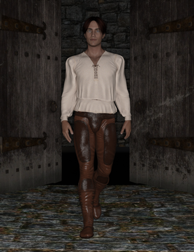

“The innkeeper said it housed more people than horses.”, The Tailor continued, “I doubt anyone actually travels *to* this place.”

He looked around again: the agitated lantern animated the shadows. “We have ourselves a stable situation.”, he laughed at his own play on words and continued: “If more people stay here than horses, it explains everything.”

Suddenly The Tailor turned towards the door. “I have to settle up with the innkeeper, and get us some food. I’m really hungry.” Then he left.

Tom looked between Kim and the cow. Both were settled and looking ready to sleep. The shadows moved with the lantern but more gently. She thought to get up and give it more swing, but was not sure she could escape the hay.

Time passed and Tom almost drifted off to sleep when The Tailor returned. Carrying three bowls, balanced with grace, and the rich smell of gravy. He handed one bowl to Kim, who sat up quickly surprised. A chunk of bread and a wooden spoon added to the surprise, Kim was unsure what this all meant, or what had just happened.

The Tailor planted the same on Tom, then sat in Tom’s adjacent section. He happily spooned the broth. Kim and Tom, however, still held their bowls, bread and spoons as when handed to them. They looked at The Tailor open mouthed. He stopped eating, pointed his spoon to his bowl: “It’s better than it looks, I promise.”

Tom and Kim took their cue and started eating. It was simply the finest broth Tom had ever tasted, and the freshest bread.

Butter, bread and broth.

“This is the life.”, thought Tom, looking through the open door as she ate. So it was (and not that Tom knew) she was looking southwards. She brought fantasies of The Tailor’s stories to mind, and embellished them with broth like this.

The south had broth and hay beds fit for princes.

# Chapter Four

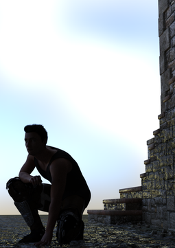

Meanwhile, far south, in the most south city, in the southern part of the kings castle, itself in the cities south, an heir to the throne, the crown prince himself, was looking out northwards.

He had the life of a prince. However, if he knew where Tom was, or even who Tom was, he would have been jealous of her life tonight.

No more was he a prince in his mind. To him, being an heir to the throne was like being a caged creature: trapped because of his specific bloodline. But soon he would be free.

For a long time he had been preparing himself a new identity: the appearance and paraphernalia to pass as one of the kings many knights. The most difficult item to acquire: a genuine ‘knights ring’. It was also the most necessary piece.

He looked out northwards: the dusk lit city below the castle battlements. It was time, so he went inside. The stone walls of the south tower were deeply cold.

His pack was ready: his formal knight’s robe, his standard knight’s armour; laid out in neat pieces. He had his ‘letter from The Prince’ he had written, as part of his cover story. It was safe in his pouch. His disguise complete.

Knights armour had slightly different strapping compared to the princely armour he was familiar with. But he had prepared and practised, and was soon encased in his new metal shell. Dressed in his overrobe, his pack on his back, he was almost ready.

The heavy helmet and visor were the last parts. These amplified his own breath and cropped his vision. The discomfort a reassurance; it would be a good disguise.

The south stair was as deserted as expected, his rattling armour unheard. He followed the spiralling stairs down to the arched tunnels below the keep.

Through the tunnels, each step brought a creeping remembrance of what he was escaping: the responsibility, the throne and the honour of his lineage. There it was, the shame on his shoulders.

But then a flash of what lay ahead: the open road, a life of freedom, to hide away from chains of state. Instead be alive day to day; each morning living a new life. Each morning free again.

So he took more steps, faster steps. But hurrying did not abate the remorse. Regret pushed against guilt to a blur. And a new flash of regret: not preparing a torch for this tunnel escape, it was dark. He had packed a bundle of torches (he had packed everything useful he could think of).

“I could stop and get the torches out…” he thought, mentally navigating through the layers of compacted equipment. He knew the location of everything in his backpack, each item crammed to it’s smallest possible bundle.

He would have to take his helmet off to do that. He might be out of the tunnel soon.

More steps forward but misplacing his footing, and almost stumbling, caused him to slow down. He felt a draft of air, the tunnel must conclude soon. “Am I doing the right thing?”. He felt anxious. He stopped. The weight of his pack, the weight of his helmet, but mostly the weight of his choice.

His stomach churned.

The breeze stronger, the cold biting his eyes. And the sound of rushing. It was the sound of rain. Listening, somehow, the prospect of rain was exhilarating; there was little rain in the life of an heir to the throne. Yet here he was, a few steps away.

The tunnel narrowed and led round to the left. Following this, the smell of rain and the outside. The tunnel became a narrow cave and an opening overlooking fields.

Looking out of the cave, into the misty rain, his anxiety rose; the prospect of the constricting life behind him, the escape to freedom in front. The sound of the rain neither diminishing or increasing; it was a flat boring constant he found himself aching for.

He stepped forward, the rain ringing each hit on his helmet, deafening him. Footing was difficult in the wet mud, which made progress humorously slow. His wet robe becoming heavier. A field’s fence a major obstacle.

And so his first steps went, travelling near blind in the dark; reluctant to take his visor off, even after tripping into a ditch, and climbing out the other side. Fields seeming to go on forever, the night never ending.

Until morning broke and the rain stopped. For the first time he dared to look back: the castle far in the distance, but not that far… far enough.

He had calculated that first light would be the time people noticed he was missing. Now with the sun he could find north, latch onto a suitable trail and follow this as far north as possible. Right up to The Expansive Forest perhaps?

In the north, for Tom, The Tailor and Kim the weather was dry. There had been no rain that night. Tom woke later than usual; it was already light. Groggy and disorientated she feared she had overslept her family. With great relief she remembered where she was, the sense of liberation was a surprise. This was the first time Tom recognised the burden of life at home.

Still groggy she pulled her calves taught; stretching her feet to a point, arms arching back. The stretch brought a wave of lucidity.

Dust darted through sunbeams from knot-holes. She had nothing to worry about.

But there was something wrong.

Kim and the cow had gone. She instantly knew what this meant: he was telling her to go.

Her feeling of comfort dislodged. She sat up to reassess. The Tailor was asleep. Kim and the cow were still gone.

Getting up quietly Tom took a few careful steps towards the door, pushing it open; enough to peek outside. There was no trace of her brother.

Pushing the door more, she stepped outside looking in the direction of The North Trail. Kim and the cow were long gone, no trace of either.

Tom stood looking northwards, imagining how far Kim might have gotten. The cow was slow, he would be close. She could catch him up, it would be easy.

But she could not take a step; blocked by an elusive, buried reason. She did not want to become aware of the reason. Wherever he was, Kim was walking away, slowly. Again, she thought she could catch him up.

Kim was telling her something though. He had travelled without her deliberately. The elusive reason gaining painful clarity: home was danger.

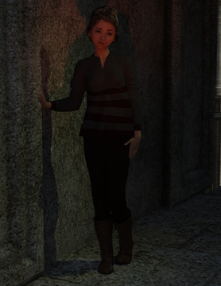

The hay inside had lost it’s bliss, but it felt like the closest thing she had to a home right now, so she went inside.

The Tailor was sitting up, looking at her. His face and eyes showing sympathy. She thought to herself: “Could I live here? Would The Tailor live here?”. She looked at him. “Would you live here?”, and then: “Where are you going?”. The words tumbling out, she did not mean to say that.

But he thought about this, then waved the question away: “That’s a rather deep question for the morning.”. He lounged back stretching. “We can philosophise later. Lets have breakfast first.”

Tom deduced she was welcome to be with The Tailor for the foreseeable future, which was breakfast.

Breakfast was as delicious, if not more so, than the stew the previous evening: eggs, bacon, dark bread and butter. Tom sneaked what she could into her pocket; a sausage. There was no way to put the potato in her pocket, it was too crumbly. So she finished it all, licking her tin plate clean. “Do you eat like this all the time?”

“I try not to.”, he replied, pushing his empty plate forward. He cocked his chair on two legs, leaning the chair the wrong way, his back against the wall instead of the chair’s back.

“You asked me where I was going?”, he shuffled into a more relaxed position. “I’m a travelling tailor, I just travel.”

Then, as if he had remembered something, he added: “And I do tailoring.”, using his finger to accentuate.

“What’s tailoring?”

Leaning forward, a mirthful twinkle in his eye: “I thought you’d never ask. Let’s go and show you tailoring.”

To which he stood up and walked towards the inn’s door, beckoning Tom with his head; “Come on.”, a jaunty walk. He was enjoying this.

Outside, Tom stood in a ridiculous way, her arms out straight and her legs apart. The Tailor worked under each of her arms with pins in his mouth. “And I’ll do something with your hair.” he tried to say.

“What are you doing?”; tones of anxiety. He took the pins out of his mouth.

“I’m bringing your jumper in, so it fits better around the shoulders. And waist.”, then he paused, pursing his lips, finally adding: “I say fits better, but what I mean is: fits better than not fitting whatsoever.”

She felt exposed standing like this, but she trusted what The Tailor was doing; it must be important for travelling. He continued to sew around each underarm, and similarly on her trousers.

He drew her away from a small pile of fabric she was now standing in, and sat her down on a milestone, explaining: “Now I’m going to sort your hair out.”

She could see some of what he had done to her jumper. It was less baggy, with thick, long stitches across each underarm. On her trousers, the excess length of trouser leg had been cut off and seamed, instead of roll-ups. But there was no opportunity to look closer. Between looks, her head position was adjusted by a gentle hand. Sometimes, but not always, it was accompanied by the sound of snipping.

“There…”, he said, bringing a small mirror to her face. Her hair had well-defined steps, but was still shaggy. “Just a tidy.”, he underplayed, and then he paused. For a moment, he looked like he was going to say something, but he let it pass.

Moving her arms around, testing her jumper, she was surprised at the lighter feeling. “That’s good.”, she said, instantly regretting the vocal impulse. Kicking her legs, she inspected each landing. Now her trousers covered her boots more, which was convenient.

The Tailor looked at her expectantly, as if she was going to elaborate. But she nodded with the minimum of approval. “The next town’s not far”, he said, changing the subject, “we’ll make it before lunch.”, and he turned southwards: “It’s got the third worst inn in the world, you have to see it to believe it.”, he laughed. “Lets go.”

Her clothes felt different, her hair felt different. They started walking. Suddenly, she realised she had a friend. And absolutely no idea where she was going.

# Chapter Five

The Prince was glad to find a trail, being tired of fields, forest and ferns. A biting chill with little sun, at least not since the bright morning.

His clothes and pack soaked through. His muscles ached; he had never walked so far, with such weight. He could not stop yet though. The tall holly hedges obscured a hut which came into view round the corner. A small opening with stables, a wooden shack and a grain silo.

The Prince stood outside the shack. The buildings were maintained to a high standard. A neatly painted door opened and an old man in a leather apron looked at The Prince.

“Greetings.” The Prince declared, as a Knight would.

“Look at you, what a mess.” the old man replied informally. “You’d better come inside.” and left the door open as invitation. The Prince entered. A small room, bare wooden walls with a long trestle bench along the facing wall. The man had gone through another door to his left, which was open. The old man came back with an arm full of a folded robe, rough towels and underclothes.

“Were you chasing a bolted horse all night?” the old man dryly questioned, “through a stinking marsh?”, snorting a laugh. The Prince flinched to respond, thinking fast to adapt his excuse, but the old man cut him off; “No! Don’t explain, I don’t want to know. If I wanted to know things I wouldn’t have gotten myself stationed at this outpost.”

After putting the bundle of clothes on the bench, he noticed the open front door which he closed, giving The Prince an accusing glare. Seeing the pathetic soaked knight, the old man shook his head and patted The Prince on the shoulder: “Get yourself dry young man, can’t have a knight looking sorry for himself.” and left through the other door, closing it behind him.

The Prince squatted to rest the weight of his pack on the bench. Easing the straps off each shoulder. The release of weight was immense relief. Now only the weight of his plate armour, helmet and the sodden robes, he felt as light as a feather. He sat next to his pack and relaxed.

“People close doors after them.” he thought to himself, cursing quietly, “What else do I need to know?”

He removed his helmet and pulled his gauntlets off. Wrinkled, numb fingers awkwardly tried to unbuckle the straps on his greaves, and then each of the other, numerous, straps, clasps and buckles.

With his armour removed, towel in hand, he was dry. Now he understood the towel was an important piece of equipment. He had not packed any towels.

The new clothes were mostly the same as his previous, since they were all standard knight issue. But the new overrobe had an older variation of the royal insignia; old, from his grandfathers reign. He wondered how many years it had been in storage.

His previous clothes were in a puddle-pile on the floor. He stared at them, thinking they would be cleaned and dried, and then put into storage. His backpack, still soaked, a reluctant burden. He would get used to the weight. With his helmet on, and visor closed, he was almost ready to return to the trail. Just gather some more strength first.

“Are you asleep?”; The Prince awoke to see the close up face of the old man; peering into his visor. “I was.”, he replied, falling back on honesty in his waking daze. The old man walked off laughing. The Prince felt refreshed. “I had better move myself on,” he thought, “Before I fall asleep again.”.

“I will continue on my journey now.” he called out to the old man, standing up, more slowly than intended. As he stood he regained his persona as a knight, readjusting his helmet so it was straight.

“Good.” replied the old man, shouting through the open doorway. “Nothing personal,” he added, poking his head through the doorway, “I like you as much as I like anyone, and I don’t like anyone.”, he explained, wiping his hands with a cloth.

“I very much appreciate your assistance.” The Prince said formally, then, looking in the old man’s eyes, added: “Thank you.”; his sincerity ruining the formality.

The old man was pleased with this. “Go on, off you go.”, he shooed The Knight out of the main door, “You might be less annoying than most, but you’re still annoying.”

Walking along a rough path, a field on one side, a short stone wall the other, The Prince could barely keep his eyes open. He had been walking for a short time.

The wall stopped at a grove. On one side the field continued, the other: a thick meadow seemed to go on forever. A fallen tree invited him to sit down, promising a comfortable seat. He had not seen anyone else since leaving the old man’s hut, and he was too fatigued to care about being recognised. He took his helmet off, resting it against one of the fallen tree’s branches.

Working his pack off his back, he sat on the fallen tree and almost instantly fell asleep.

When The Prince woke the wind had picked up, the branches whistled. Clouds had gathered, it looked like a storm might be coming. This was exciting, a chance to use his equipment. But more than that, he felt that his life on the road was beginning.

With his gauntlets off, he pried the pack’s buckles open. The canvas backpack was soaked through, the straps were difficult to work free.

Unbuckled, he pulled out his large, tarred canvas sheet. It would make his tent. Unwieldy in the wind, the large sheet flapped wildly. The first peg driven quickly into the ground with a stomp. He fastened the other corner of the sheet to the edge of his makeshift seat. It was a crude bivouac, but it should suffice. Some more driven pegs and The Prince thought he had built enough of a shelter to withstand the weather.

Inside the makeshift shelter, shielded from the wind, he nestled down and listened to his internal chatter. It fed him concerns which he dismissed; the isolation giving him safety. Wind outside barraged unsuccessfully, whipping aggressively. But the pegs, the rope and the canvas won decisively. With each victory The Prince fell deeper and deeper into sleep.

Birdsong woke him. He peered out of the tent; it was afternoon, the sky had cleared. He felt more awake.

The winter sunshine was on his face and he felt good. There was no storm earlier bringing relief of easier travelling, hampered only by a slight disappointment; it was not a true test.

The tarred sheet did not pack well. Methodically rolling it tight, there was a figure in the distance. He could not see much about them, except for their striking red robe. It was a good sign though, seeing someone travelling from the direction he was going. The trail did, at least, go somewhere.

By the time he had finished rolling the sheet, the figure was close enough to see, but too far away to speak with. It was a young woman, she lowered her red hood and waved cheerfully. He interrupted his two handed packing to respond with a quick knight’s salute.

Once the taught, canvas bundle was crammed back into his backpack, and the straps pulled tight, he squatted to shoulder the straps, taking a breath before bearing the full weight.

“Hello.” the young woman interrupted.

“Greetings.”, he replied while shuffling the weight of his pack, adjusting the straps. Then, as fast as possible he grabbed his helmet off the fallen tree and put it on, covering his head. He left the visor open.

“Are you making a camp?” she asked.

“No, I’ve just packed everything up.”

She seemed disappointed. “Are you travelling north?” she asked hopefully.

“Yes.”, he offered, but she had been travelling in the opposite direction.

Before he could think what to say she quickly asked: “Would you join me? We could travel together.”

“I’m not sure if you’re aware, you were travelling southwards. I’m going the way you came.”; he felt he had to say that.

“I’ve been lost for a while. I wanted to avoid the main roads, but it’s hard to keep track of direction, …I’m not on trails I’m familiar with.”

The Prince nodded in understanding, although he himself knew several ways to identify north. Not everyone had such training. “To accompany you would be a duty and an honour.” he responded earnestly.

She looked The Knight up and down, balancing her weight on one leg, the other crossed behind it on point. She held her hands behind her back. “That’s what I thought.”, the conclusion carrying her satisfaction. “Are you a knight errant?”

“Yes.”, his disguise working, “I am.”

She seemed impressed. “I’m on an adventure myself, I need to get far north, and I can’t use the main routes. I do what I want now.”

The Knight nodded along with her words, as if they made sense. He was exhilarated to have some travelling company; better cover for his escape.

“I’m Red,” she beamed a warm, welcoming smile, “I’m really pleased you’ll join me.”

But not as pleased as The Knight, it was all going rather well. Their common goal: to travel far north and stay off the main trails.

As they walked together, along the way Red had come from, The Knight provided conversation: replaying his rehearsed lines, where he had come from, his knight’s vows and how these may effect his behaviour. Red offered no doubt, she was delighted with all parts of his script.

Once he had finished his well rehearsed spiel, a comfortable silence settled. Red pointed ahead; “There’s a beautiful spot on the edge of the meadow, a small stream next to a clearing. It’s hidden by a bramble thicket. I’m surprised I found it.”

To The Knight this sounded ideal.

Red and The Knight sat by the stream. The fire was building strength; wet blankets, from The Knights pack, propped up with sticks to capture the warmth. The half empty pack itself, planted just beyond the fire’s range, sat as a centre-piece to the evenly strewn contents; a tiny city of equipment. Two small tents, in parallel, looked ready; their entrance sheets open in identical fashion.

The midday sun felt good, and with the fire’s warmth, The Knight started to feel like he could be warm again. Red had pulled her hood over her head and was humming a gentle melody. Listening, he heard contentment. It elevated the mood. The stream was interesting viewing. Too shallow for fishing, he will be cooking his standard issue rations tonight.

Red finished humming, the crackle of the fire taking main stage; popping a spark, it gently collapsed on itself. The Knight pushed himself off the ground and added three logs. A quick appraisal and he turned back to the stream, resuming his place next to Red.

There was no talking. The Knight took mental inventory, thinking through his groups of equipment: cooking, cleaning, engineering, repairing, fighting. Having set up camp, he was more aware that his items were now his home and his life.

Red hunched over a small, open papyrus codex. The feather end of her raven quill exaggerating the slow, careful swirling of the writing. The Knight noticed a tiny, elegant ink bottle tied to a cord around her neck. He himself had some ink, sealing wax and parchment, but it was for official knight’s business only. Like his, her feather was a pinion; an optimum feather for a quill, he was somewhat impressed.

As the afternoon drew in, the blankets dried and the fire became a stove. They dined on a knight’s banquet of dried meats, pickled vegetables and fruit preserves. Despite his earlier rest he began to feel fatigue catch him up. “I’ll take an early rest. I’ll be awake again in the early hours to take over the watch.”. Red understood and was fine with this arrangement. She placed two more small logs on the fire and slouched back, watching the fresh logs adapt to their new home.

# Chapter Six

All this time while The Knight and Red were meeting, wandering northwards together, and stopping to make their camp in the thicket clearing, Tom and The Tailor were travelled southwards.

“Here it is.”, The Tailor pointed towards the town ahead. Tom wanted to stop and rest but The Tailor sped up. “I need to see the smithy, get a few things while we’re here.”, but he did not mention the stench of rotting vegetables.

Somebody was slumped on the floor in front of them, vaguely against the side of a building; stretched out, blocking their path. “He’s drunk.”, The Tailor explained and they manoeuvred single file around him.

Weaving through alleyways, made from competing buildings, they startled rats which darted away panicked. Judging by the size of the rats, and the smell of the rotting food, Tom knew that the people here ate well.

Leaving the maze of buildings they entered a muddy clearing, which soon led to a high, intimidating wooden wall. The Tailor seemed to know where he was going but walked straight towards the wall. But then Tom could see a door which almost blended into the wall. She could hear a crowd on the other side. As The Tailor opened the door, Tom was inundated with a bewildering array of sights and sounds.

Bustling people shuffled around market stalls, stretching into the distance. What looked like an oppressive wall on one side stopped short, in ruins, before it could even make a semicircle around the market.

The Tailor stepped to one side pulling Tom with him. He looked across the stalls, she could smell chicken being cooked. Further away, over the sound of the crowd, a piper played a frantic series of scales. Somebody shouted at them. Tom quickly looked up, but it had nothing to do with them, it was for somebody else. The Tailor took a deep breath: “This is where trappers and miners meet.”, he shared, regretfully. “Come on, let’s get this over with.”

Tom fell in behind The Tailor, it was easy following his steps through the crowd. Her attention lost to the busy businesses around, each stall an entire world. One had many hanging, dried meats. Its neighbour: a stall displaying increasing sizes of metal hoops, with long, thin, wooden poles laying next to them. Tom wondered what these were for?

On the far side of the muddy walkway, through a happenstance gap in the crowd, a vendor, surrounded by tall bolts of multicoloured cloth. He was arguing with a rotund customer. Behind her somebody burst out laughing. But the cloth merchant’s shrill voice pierced through, angry in a language she did not understand.

Hurrying past, they walked towards a steady, metallic banging. It had just started; pulses of three. Each hit rattled the back of Tom’s teeth, but its echo played a beautiful tone. “Oh good, he’s here.”, The Tailor exclaimed. He extended his arm towards Tom, “Climb up.”, and Tom scrambled up The Tailor’s side to his shoulders, easily finding steps.

The view was spectacular, an image she would never forget: the variety of people, clothes, fully laden trestle bench stalls. The crowd bobbed, a sea of heads. She traced the sound of the banging: a large circular stone building in the centre of the market, thick smoke plumed from it’s chimneys. They walked towards it.

At the blacksmith’s entrance The Tailor did not break stride to pass under the doorway. Instead, he squatted mid-stride, and Tom cricked her neck sideways. Inside, The Tailor stopped; flinching from the heat. For a moment Tom thought her lips might burn.

In front of them stood three men around an anvil. One hammered a glowing strip of metal; it shot angry sparks in defiance with each hammer blast, but the blacksmith’s leather aprons took the angry sparks impassively. The three blacksmiths were focused on their their task, they didn’t react to Tom and The Tailor or seem to noticed them.

The Tailor stood there watching them from where he was standing, immediately inside the doorway. Tom wanted him to move, they were both blocking the doorway. She fought a rising anxiety being conspicuous and bold in the space The Tailor chose. She slowly slid off The Tailor’s shoulders behind him, as out of sight as possible. Two people approached as she landed on the floor, she partially watched: a large, burly man and a tall thin boy who straddled just behind him.

“Hello again”, The Tailor said cheerfully to the burly man.

He responded with a grunt. “You’re back again. I suspected you were an idiot. But now I know you are.”

“I couldn’t stay away”, The Tailor explained, shrugging. The burly man responded by snorting a curt laugh. He was about to say something else but the three at the anvil started banging again, which interrupted him. He gestured to the thin lad, who left, then herded Tom and The Tailor back outside through the doorway. The bright dazzling sun and sharp cold wind were stark contrasts to the dim, hot workshop.

The burly man flinched, squinting from the light but not the chill as he raised his bare, scarred arms to shield his face from the sun. “So admit it idiot, you’re lost.”.

“No.” and The Tailor gazed over the market town, as if assessing it for the first time. “I obviously came back to admire your town and your face again. Perhaps make an oil painting of them. That and your fabulous inn.”. He jerked a thumb behind him, pointing to the filthy Inn on the other side of the wide trail behind them.

The burly man snorted, “Then we’ve got some whores you should meet. Paint *them*. That and my fat hairy arse.” He brought a small, wooden pipe to his eye, squinting inside. He rapped it twice, sharply against the building’s wall.

“We won’t stay long though.” The Tailor added, “Just a quick pass-through holiday this time.” Tom listened to The Tailor’s words. She knew he was being sarcastic. But to her, it was a holiday.

The burly man extended his arm, pointing behind them. Tom and The Tailor turned. “Look, one of the local holiday sights:”, The burly man dryly captioning a staggering drunkard, half-tripping out of the Inn’s door. The drunk man recovered his steps and slowed his walking. But then stopped. He seemed unsure for a moment. But then he was sure and quickly bent forward, dropped to his knees and vomited along the path in front of him. The splattering went far along down the path.

The burly man looked back towards the pipe in his hand. He pinched leaves from a small leather pouch in the other. He glanced a nod towards the drunkard: “Looks like you’ve got a rival artist.”

The Tailor laughed.

The burly man and The Tailor continued to exchange dry, insulting jibes. That, and sarcastic commentary on the comings and goings around them. She found the sarcasm strenuous, being unfamiliar with the targets of satire. The sarcastic tones of voice misleading. Solid information, that she tried to grasp, elusive.

She turned to look at the burnt-out wall. The banging chimes from the smith rang beautiful echoes around the market. The noisy bustle from the crowd occasionally accented by laughs from The Tailor and his friend. She had no idea what they were talking about any more, but it made her smile.

# Appendix A-1

## Red Riding Hood

[figure not shown]

| `@}}>-----` | ~ | `--------{---(@` |
| --- | --- | --- |
| Class | : | Rogue 1 |
| Race | : | Human |
| Hit Points | : | 7 |
| Alignment | : | Gangster / Indifferent |
| Base Attack Bonus | : | 0 |

### Attributes

| Attribute | n/18 | Mod. |
| --- | --- | --- |
| Strength | 7 | (-2) |
| Dexterity | 14 | (2) |
| Constitution | 12 | (1) |
| Intelligence | 14 | (2) |
| Wisdom | 9 | (-1) |
| Charisma | 16 | (3) |

### Saves

| Save | Rank + Mod. (+Special) | Score |
| --- | --- | --- |
| Fortitude | 0 + 1 | = 1 |
| Reflex | 2 + 2 | = 4 |
| Will | 0 + -1 + 2 (*iron will) | = 1 |

### Melee

| `@}}>-----` | Mod. | Score |
| --- | --- | --- |
| Initiative | 2 + 0 | = 2 |

| Attack | Base + Mod. (+ Special) | Score |
| --- | --- | --- |
| Melee | 0 + -2 + 0 | = -2 |
| Ranged | 0 + 2 + 0 | = 2 |

**She doesn’t fight**

She might smash a big porcelain Jug over someones head, `1d2+1 (-2 Str.) point of subdual damage`

But she knows all the bandits, robbers and low life, they work for her dad

And the Kings Knights think her dad is a hero, and she is well known, and well in favour with them

She’s got it all sorted, who’s she going to smash a jug over?

She can throw a rock I guess `1d2 (-2 Str.) bludgeoning damage` but as you can see it won’t do any damage

| `@}}>-----` | Mod. + Base + Armour | Score |
| --- | --- | --- |
| Armor Class | 2 + 10 + 0 | = 12 |

### Skills

| Skill | Ranks + Mod. (+ Special) | Score |
| --- | --- | --- |
| appraise | 2 + 2 | = 4 |
| bluff | 6 + 3 | = 9 |
| craft (weaving/sewing) | 4 + 2 | = 6 |
| diplomacy | 2 + 3 | = 5 |
| intimidate | 6 + 3 (+ 4 *connected) | = 13 |
| knowledge (local) | 4 + 2 | = 6 |
| listen | 4 + -1 | = 3 |
| perform (dancing) | 4 + 3 | = 7 (*local celebrity possible +2 bonus) |
| sense motive | 4 + -1 | = 3 |
| sleight of hand | 4 + 2 | = 6 |
| spot | 4 + -1 | = 3 |
| ride | 1 + 3 | = 4 (preference for side-saddle) |

### Feats

| Feats |  |
| --- | --- |
| iron will |  |
| persuasive |  |
| connected | *1 |
| local celebrity | *2 |

`*1 (well known gangster family. +4 bonus to intimidate)`

`*2 (gets a +2 bonus to perform when performing to those who know of the performer. Also 1D4 close friends in any town she's performed in. With Red this is typically a large group of girl-friends, 1D4 of which are in her inner circle)`

### Languages

Common, Thieves cant (*aka peddler’s French*)

(note she can learn two more languages (*Int. bonus of 2*)

# Appendix A-2

## Tom Thumb

[figure not shown]

| `@}}>-----` | ~ | `--------{---(@` |
| --- | --- | --- |
| Class | : | Ranger 1 |
| Race | : | Human |
| Hit Points | : | 7 |
| Alignment | : | Feral / Loyal Benevolent |
| Base Attack Bonus | : | 1 |

### Attributes

| Attribute |  | n/18 | Mod. |
| --- | --- | --- | --- |
| Strength |  | 8 | (-1) |
| Dexterity |  | 16 | (3) |
| Constitution |  | 8 | (-1) |
| Intelligence |  | 17 | (3) |
| Wisdom |  | 17 | (3) |
| Charisma |  | 17 | (3) |

### Saves

| Save | Rank + Mod. | Score |
| --- | --- | --- |
| Fortitude | 2 + -1 | = 1 |
| Reflex | 2 + 3 | = 5 |
| Will | 0 + 3 | = 3 |

### Melee

| `@}}>-----` | Mod. (+ Special) | Score |
| --- | --- | --- |
| Initiative | 3 (+ 4) | 7 |

`(+ Improved Initiative)`

| Attack | Base + Mod. | Score |
| --- | --- | --- |
| Melee | 1 + -1 | = 0 |
| Ranged | 1 + 3 | = 4 |

*She hides to avoid this but if cornered she will fight for a chance to run when possible*

- Stool leg `1d3 (-1 str.) bludgeoning type damage (×2 on critical)`
- Rock `1d2 (-1 Str.) bludgeoning type damage (×2 on critical)`
- Unarmed strike (small being) `1d2 (-1 str.) bludgeoning type damage (×2 on critical)`

  note improved unarmed strike means this is real damage not subdual damage, sure it’s between zero and one point of damage. This means it would take about fourteen attacks for Tom to actually kill someone (with seven Hit Points). Not that she would because its not in her nature. Just reading the model. Her punches always leave a bruise, and like a swan it’s possible she could break someones bone (critical hit doing 4 points of damage). Not in Toms nature at all but, yeah you get a bruise

| `@}}>-----` | Mod. + Base + Armour | Score |
| --- | --- | --- |
| Armor Class | 3 + 10 + 0 | = 13 |

### Skills

| Skill | Rank + Mod. | Score |
| --- | --- | --- |
| balance | 2 + 3 | = 5 |
| climb | 2 + -1 | = 1 |
| escape artist | 1 + 3 | = 4 |
| heal | 2 + 3 | = 5 |
| hide | 4 + 3 | = 7 |
| jump | 2 + -1 | = 1 |
| knowledge nature | 4 + 3 | = 7 |
| listen | 4 + 3 | = 7 |
| move silently | 4 + 3 | = 7 |
| search | 4 + 3 | = 7 |
| spot | 4 + 3 | = 7 |
| survival | 6 + 3 | = 9 |
| tumble | 2 + 3 | = 5 |
| use rope | 4 + 3 | = 7 |

### Feats

| Feats |  |
| --- | --- |
| Improved Initiative |  |
| Self sufficient |  |
| Simple weapon proficiency |  |
| Favored enemy (rodents) |  |
| Dodge |  |
| Improved unarmed strike |  |
| Cunning fist | *1 |

`*1 (same as Stunning fist but -2 to armour class until your next turn and only a 25% chance of success. Can not be used twice on the same target.)`

### Languages

Common

(note she can learn three more languages (Int. bonus of 3))

# Appendix A-3

## The Knight

[figure not shown]

| `@}}>-----` | ~ | `--------{---(@` |
| --- | --- | --- |
| Class | : | Fighter 2 |
| Race | : | Human |
| Hit Points | : | 20 |
| Alignment | : | Fugitive Royal Prince / Decent Bloke |
| Base Attack Bonus | : | 2 |

### Attributes

| Attribute | n/18 | Mod. |
| --- | --- | --- |
| Strength | 16 | (3) |
| Dexterity | 12 | (1) |
| Constitution | 16 | (3) |
| Intelligence | 16 | (3) |
| Wisdom | 14 | (2) |
| Charisma | 9 | (-1) |

### Saves

| Save | Rank + Mod. | Score |
| --- | --- | --- |
| Fortitude | 3 + 3 | = 6 |
| Reflex | 0 + 1 | = 1 |
| Will | 0 + 2 | = 2 |

### Melee

| `@}}>-----` | Mod. | Score |
| --- | --- | --- |
| Initiative | 1 | = 1 |

| Attack | Base + Mod. | Score |
| --- | --- | --- |
| Melee | 2 + 3 | = 5 |
| Ranged | 2 + 1 | = 3 |

He’s trained in all arms and armour

He’s well trained here too: bows, crossbows, spears, etc

| `@}}>-----` | Mod. + Base + Armour | Score |
| --- | --- | --- |
| Armor Class | 1 + 10 + 7 (Half-plate) | = 18 |

### Skills

| Skill | Rank + Mod. | Score |
| --- | --- | --- |
| concentration | 2 + 3 | = 5 |
| disguise | 1 + -1 | = 0 |
| handle animal | 7 + -1 | = 6 |
| intimidate | 5 + -1 | = 4 |
| craft (arms and armour) | 1 + 2 | = 3 |
| profession (crown prince) | 3 + 2 | = 5 |
| ride | 2 + 1 | = 3 |
| knowledge (nobility) | 3 + 3 | = 6 |
| knowledge (anything else *royal privilege) | 0 + 3 | = 3 |

### Feats

| Feats |  |
| --- | --- |
| simple weapon proficiency |  |
| martial weapon proficiency |  |
| shield proficiency |  |
| tower shield proficiency |  |
| armor proficiency light |  |
| armor proficiency medium |  |
| armor proficiency heavy |  |
| combat expertise |  |
| combat reflexes |  |
| power attack |  |
| animal affinity |  |
| royal privilege | *1 |

`*1 (has knowledge in any subject as if untrained, +15 to intimidate & persuade when speaking as The Prince to his kingdom)`

### Languages

Common

Three other known languages

# Appendix A-4

## The Tailor

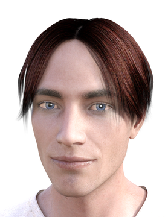

| `@}}>-----` | ~ | `--------{---(@` |
| --- | --- | --- |
| Class | : | Bard 3 |
| Race | : | Human |
| Hit Points | : | 15 |
| Alignment | : | Incognito / Benevolent Mentor |
| Base Attack Bonus | : | 2 |

### Attributes

| Attribute | n/18 | Mod. |
| --- | --- | --- |
| Strength | 12 | (1) |
| Dexterity | 18 | (4) |
| Constitution | 12 | (1) |
| Intelligence | 16 | (3) |
| Wisdom | 14 | (2) |
| Charisma | 18 | (4) |

### Saves

| Save | Rank + Mod. | Score |
| --- | --- | --- |
| Fortitude | 1 + 1 | = 2 |
| Reflex | 3 + 4 | = 7 |
| Will | 3 + 2 | = 5 |

### Melee

| `@}}>-----` | Mod. | Score |
| --- | --- | --- |
| Initiative | 4 | = 4 |

| Attack | Base + Mod. | Score |
| --- | --- | --- |
| Melee *1 | 2 + 1 | = 3 |
| Melee light *2 | 2 + 4 | = 6 |
| Ranged | 2 + 4 | = 6 |

`*1 medium or heavy weapons`

`*2 light weapons (weapon finesse)`

Will take typically take Total Defense and on attack use disarm, feint, sunder and trip

| `@}}>-----` | Mod. + Base + Armour | Score |
| --- | --- | --- |
| Armor Class | 4 + 10 + 0 | = 14 |

### Skills

[output not shown]

### Feats

| Feats | Notes |
| --- | --- |
| simple weapon proficiency |  |
| weapon finesse |  |
| combat expertise |  |
| improved disarm |  |
| improved feint |  |
| improved sunder |  |
| improved trip |  |
| armor proficiency light |  |
| bardic music |  |
| bardic knowledge |  |
| countersong |  |
| fascinate |  |

### Languages

Common, Thieves cant

Four other languages possibly from another dimension, probably including German

# Appendix B

### A Croconossorus “Tale”

### As translated from the tablets of “ancient Hadriel” by “Majalofalic the occasional”, one summers day. Parts marked ‘unreadable’ either missing or damaged.

#### 1)

O, Croconossorus of Fable,

the noble beast of ancient Hadriel,

trusted and without dispute,

you knew the ways of the Hag’n’rahoot.

#### 2)

Keeping us safe both knight and day,  
and in the spaces and in-between,

for so many wondourous days,

in your company did we gleem!

#### 3)

So all seemed well and right and good,

but then one day on a Spike we stood.

For even in our lofty ways,

temptation came and it made us sway…

#### 4)

Those days where long , relaxed and breezy,  
but some got bored & stood un-easy.

They spoke of finding something new,

then darkness came & twisted their view…

Oh woe to us for these

Foolish few!

#### 5)

Taboos were broken and lines were crossed,

our morals they were mostly lost,

all to have a new thing to eat…

The Croconousaurus!

#### 6)

At first it was but just a few,

then before much time had passed,

most all our people had dined on it,

the flavour was un-surpassed…

#### 7)

So addictive was this brand-new taste,

that non did pause or ask…

“What about our old, loyal friends,

The Croconossorus?”.

#### 8)

So it was, it came to pass,

we all ate of it’s meat.

Blinded by our appetites,

the betrayal was complete.

#### 9)

Though Croconossorus he hoped,

this thing not long to last,

our hunger did go on and on,

our appetites so vast.

#### 10)

Until the oldest, biggest, wisest,

and most Fearsome of the beat,

did turn upon his masters,

with both claw and tooth and beak!

#### 11)

So strange was it for him to harm,

the people of this land,

that tears did flow as he attacked,

to make his mighty stand.

(it has been said that trees did grow,

where they hit our sand)

#### 12)

Then with crashing feet and snarling breath

and swish of mighty tail,

the people of all Hadriel did learn to

fear and wail !

Much woe did come upon us,

for we realised our fate…

#### 13)

As if a spell had broken,

the mist cleared before our eyes,

no more a lie to hide behind,

avoid this thing so vile.

**unreadable**

#### 14)

Then our wisest mages did convene,

to cast a spell so deep,

to take us all far from this land,

into a fold to keep.

#### 15)

A place to learn and live and grow,

seek wisdom, light and peace,

no more to harm our fellow beings,

kill man or fish or beast.

**unreadable**

#### 16)

The noble beast now all alone,

did wonder for a while.

seeing oceans deep and lands afar,

mile after mile.

#### 17)

His hope so strong, now growing weak,

for not a glimps was caught,

of his breatheren he had hoped to find,

perhaps all lost or slaught?

#### 18)

With heavy heart, he journeyed back,

to the forest of the salt.

his home of old, his place of birth,

to forget how he had fought.

#### 19)

There he found beneth the trees,

some comfort of a sort,

and held inside a glow of hope,

for happiness time-brought.